# Bulge/Disk Decomposition Cookbook

### Author: Robin H. W. **Cook**

### Date: 22 September, 2017

### *Preamble*

*In this **Cook**book, I will present the processes used to model the light profile of galaxies within the *extended GALEX Arecibo SDSS Survey* (xGASS) sample. We use various likelihood optimisation and image segmentation functions in [ProFit](https://github.com/ICRAR/ProFit "ProFit")/[ProFound](https://github.com/asgr/ProFound "ProFound") (developed by Aaron Robotham) to accurately disentangle the contributions of the compact inner region and extended outer region to the total light of a galaxy. Most of the tools and scripts used to process the SDSS data and perform the bulge/disk decomposition can be found here:* https://github.com/AstroRobin/xGASS-decomposition

## Processing SDSS Data:

### Data

The photometric data used for the bulge-disk decomposition of the xGASS galaxies comes from the Sloan Digital Sky Survey (SDSS) data release 7 (DR7) Data Access Server (DAS; http://classic.sdss.org/dr7/access/). This data release was chosen simply for the ease of access to the uncalibrated (in units of "counts") data products. One could also utilise later data releases if need be, however the image would need to be converted from the native SDSS flux units of ["nanomaggies" to photon counts](http://classic.sdss.org/dr5/algorithms/fluxcal.html).

The basic imaging products needed for the model fitting are the fpC-.fit (or drC-.fit for fits header supplemented images) files: these are the uncalibrated, corrected frames (bias subtracted, flat fielded, and with bad pixels replaced by interpolated values), as well as the psField-.fit files which contain the point spread function (PSF) fit for all positions in a particular field.

### Fields (images)

The fields are uncalibrated, meaning that they are in units of Data Numbers (The SDSS equivalent of counts); ProFit can understand these units given that the Gain and Magnitude zeropoint are also provided such that it can convert easily between counts and fluxes/magnitudes. These numbers can be found in the header of DR7 drC-.fit files as well as in tsField-.fit and fpAtlas-.fit files. More information about converting between photometric units in SDSS can be found here: http://classic.sdss.org/dr5/algorithms/fluxcal.html

### Cropping images

The SDSS frame images are far too large for use in ProFit and are most likely not centred upon the target of choice. For this reason, the user should crop the SDSS frames with their favourite cutout tool. For best use in ProFit One should ensure that the image is centred upon the galaxy and that it is large enough to include the diffuse outer regions of the object as well as including enough sky pixels to make accurate measurements of the background sky statistics. I use the astropy.Cutout2D() function in Python, but might like to use magcutoutWCS() in the magicaxis package to maintain the workflow within R. Below, I will show an example of the cutout process for [GASS111029](http://cas.sdss.org/dr7/en/tools/explore/obj.asp?id=588023669705146551) (RA = 175.56089, Dec = 20.09783) in a **python**.

```python
from astropy.io import fits as pyfits # FITS input/output
from astropy import wcs # World Coordinate System
from astropy.nddata import Cutout2D # Image cutout function
import warnings; warnings.filterwarnings('ignore') # Shush silly Astropy warnings

import matplotlib.pyplot as plt # plotting
import matplotlib.colors as mcol # colourbar scaling
```

```python
# Get the image data
fitsFile = pyfits.open("Data/drC-005225-r4-0076.fits") # Open the fits file
image = fitsFile[0].data - 1000 # There is a 1000 data number pedestal added to uncalibrated SDSS images
header = fitsFile[0].header # image header
w = wcs.WCS(header) # define the "World Coordinate System"
```

```
SDSS field image:
```

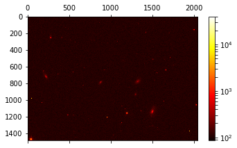

```python
# plot the image
print("\nSDSS field image:")

# plotted logarithmically for more contrast
plt.matshow(image,cmap='hot',norm=mcol.LogNorm())
plt.colorbar(orientation='vertical',shrink=0.8)

plt.show()
```

[output not shown]

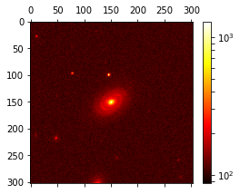

```python
# define a position
ra = 175.56089
dec = 20.09783

# Get the x,y pixel location of the target
x, y = w.wcs_world2pix(ra,dec,0)
position = (x,y)
print("Pixel coordinates:\n  x = {0}\n  y = {1}".format(x,y))

# Define the cutout dimensions (2' x 2'):
cutSize = 2.0 * 60.0 # arcsec
pixDim = (cutSize/0.396, cutSize/0.396) # SDSS pixel scale: 0.396"/pixel

cutout = Cutout2D(image, position, pixDim, wcs = w)

print("\nGASS111029 - 1'x'1 cutout:")
plt.matshow(cutout.data,cmap='hot',norm=mcol.LogNorm())
plt.colorbar(orientation='vertical',shrink=0.8)

plt.show()
```

```python
# Save image to file:
newHeader = header
newHeader['naxis1'] = pixDim[0]
newHeader['naxis2'] = pixDim[1]

newhdu = pyfits.PrimaryHDU(cutout.data,header=newHeader)
hdulist = pyfits.HDUList([newhdu])
hdulist.writeto("Data/GASS111029_image.fits",overwrite=True)
```

A nice python wrapper for this tool can be found on the [github repo](https://github.com/AstroRobin/xGASS-decomposition).